# Recalling Words

```r
library(mosaic)
library(car)
library(ggplot2)
library(dplyr)
library(purrr)
library(pander)
library(DT) #You may need to run: install.packages("DT")
```

## Background

Many teachers and other educators are interested in understanding how to best deliver new content to students. In general, they have two choices of how to do this.

1. The Meshed Approach
   - Deliver new content while simultaneously reviewing previously understood content.
2. The Before Approach
   - Deliver new content after fully reviewing previously understood content.

A study was performed to determine whether the *Meshed* or *Before* approaches to delivering content had any positive benefits on memory recall.

### Show the Experiment Details

Individuals were seated at a computer and shown a list of words. Words appeared on the screen one at a time, for two seconds each, until all words had been shown (40 total). After all words were shown, they were required to perform a few two-digit mathematical additions (like 15 + 25) for 15 seconds to avoid immediate memory recall of the words. They were then asked to write down as many of the 40 words as they could remember. They were given a maximum of 5.3 minutes to recall words.

The process of showing words and recalling words was repeated four times with the same list of words each time (four chances to get it right). The presentation of the first trial was the same for all treatment conditions. However, trials 2, 3, and 4 were slightly different for each treatment condition.

The `SFR` group (the control group) stands for Standard Free Recall. In all four trials the same list of 40 words was presented, in a random order each time.

The `Before` group also used the same 40 words during each trial. However, any words that were correctly recalled in a previous trial were presented first, or *before* the words that were not recalled in the last trial. After all the correct words were presented in random order, the non-recalled words were presented in a random order.

The `Meshed` group also used the same 40 words during each trial. However, words that were correctly recalled in a previous trial were alternated with a missed word during the next presentation order.

The data records the number of correctly recalled words (out of the 40 possible) from the fourth trial. Results were obtained for 30 students, 10 in each of the three treatment groups: `SFR`, `Before`, and `Meshed`.

```r
View(Friendly)
?Friendly

Friendly <- data.frame(
  Condition = c(rep("Before", 10), rep("Meshed",10), rep("SFR", 10)),
  Correct = c(40, 38, 39, 37, 39, 24, 30, 39, 40, 40,
              40, 39, 34, 37, 40, 36, 36, 38, 36, 30,
              39, 25, 37, 25, 29, 39, 21, 39, 24, 25)
)

head(Friendly)
```

```
##   Condition Correct
## 1    Before      40
## 2    Before      38
## 3    Before      39
## 4    Before      37
## 5    Before      39
## 6    Before      24
```

### Introduction and Hypotheses

The goal of this analysis is to determine if there are significant differences in recall scores among the three teaching methods: SFR, Before, and Meshed. Specifically, we are interested in whether the Before and Meshed methods significantly improve recall compared to the SFR (control) method.

#### For the t-Test:

- **Null Hypothesis ($H_0$)**: The mean recall scores are the same between the two groups.
- **Alternative Hypothesis ($H_1$)**: The mean recall scores differ between the two groups.

#### For the Wilcoxon Rank-Sum Test:

- **Null Hypothesis ($H_0$)**: The distributions of recall scores are the same between the two groups.
- **Alternative Hypothesis ($H_1$)**: The distributions of recall scores differ between the two groups.

These tests will allow us to assess differences in means and distributions, respectively, to understand the effectiveness of each method.

### Graphical and Numerical Summaries

# Boxplot

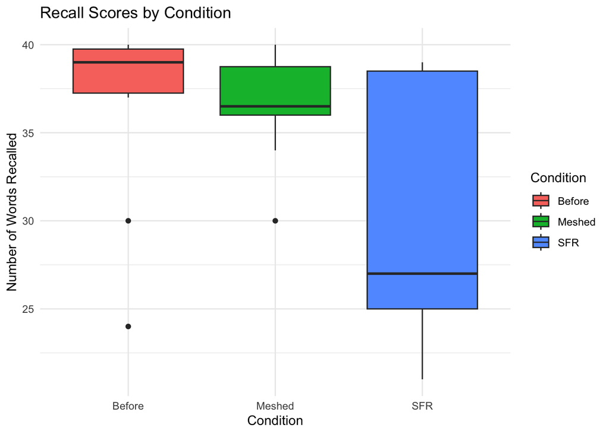

```r
ggplot(Friendly, aes(x = Condition, y = Correct, fill = Condition)) +
  geom_boxplot() +
  labs(title = "Recall Scores by Condition",
       x = "Condition",
       y = "Number of Words Recalled") +
  theme_minimal()
```

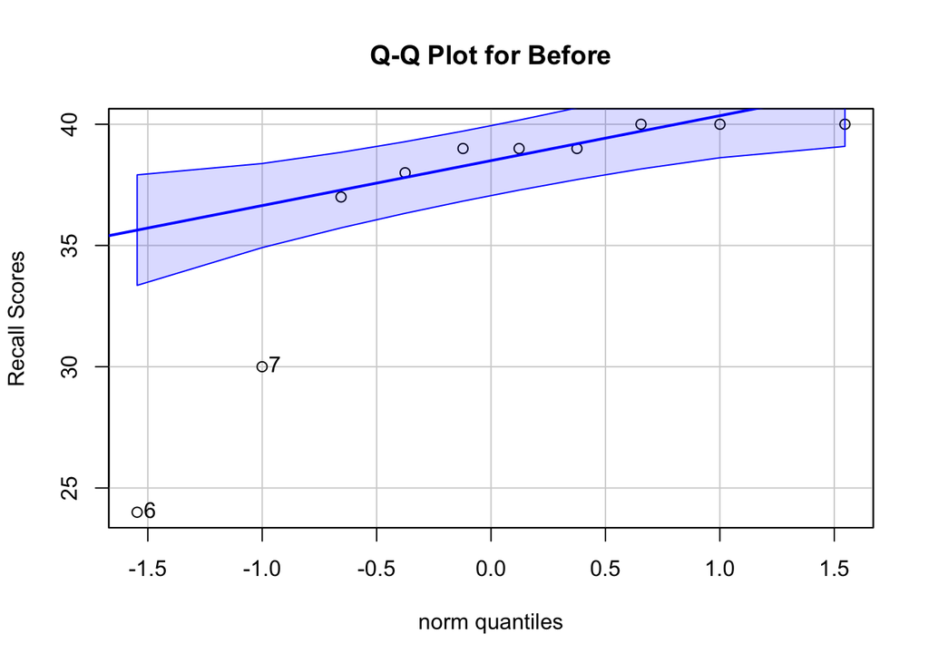

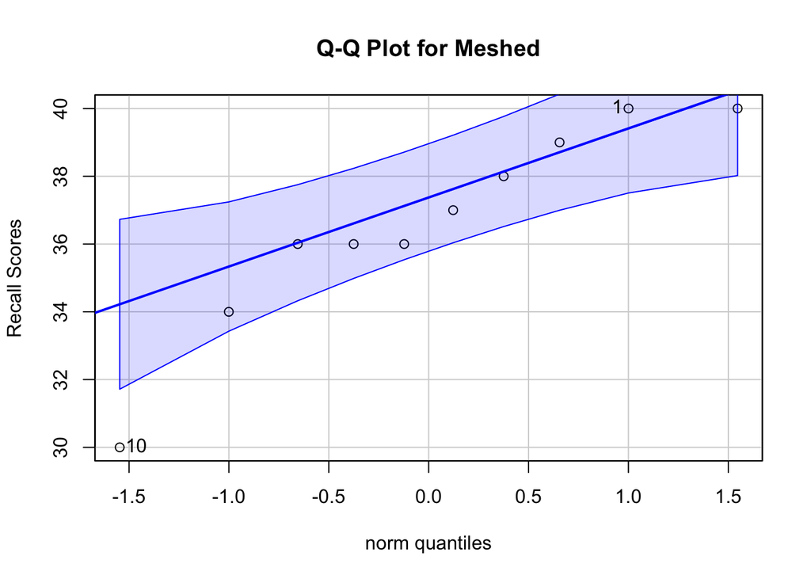

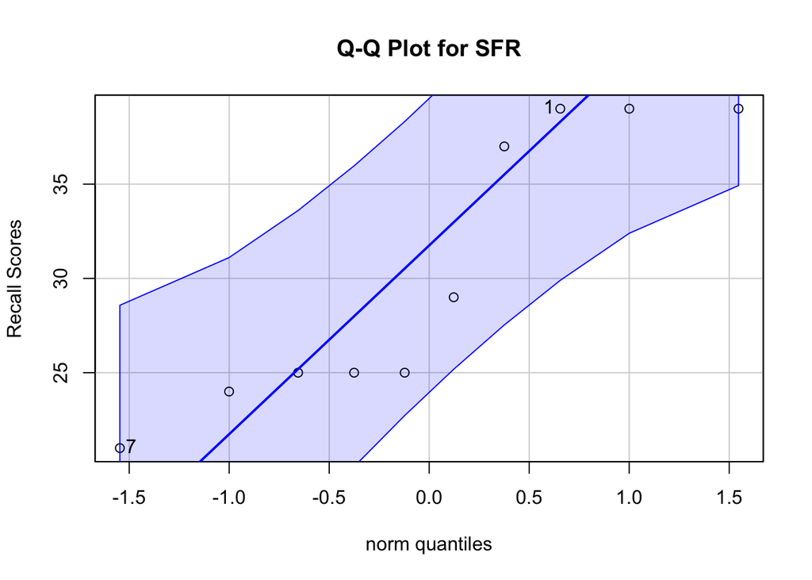

```
## $Before
## [1] 6 7
##
## $Meshed
## [1] 10  1
##
## $SFR
## [1] 7 1
```

```r
Friendly %>%
  split(.$Condition) %>%
  purrr::map(~car::qqPlot(.$Correct,
                          main = paste("Q-Q Plot for", unique(.$Condition)),
                          ylab = "Recall Scores"))
```

# Summary Statistics

```r
# Generate summary statistics
Friendly %>%
  group_by(Condition) %>%
  summarise(
    Mean = mean(Correct),
    SD = sd(Correct),
    Median = median(Correct),
    Min = min(Correct),
    Max = max(Correct),
    n = n()
  ) %>%
  pander::pander(caption = "Summary Statistics for Recall Scores by Condition")
```

Summary Statistics for Recall Scores by Condition Both the Before and Meshed groups outperform the SFR group in mean recall scores **(𝑀=36.6for both vs. 𝑀=30.3 for SFR)**. The SFR group has the highest variability **(SD=7.334)**.

| Condition | Mean | SD | Median | Min | Max | n |
| --- | --- | --- | --- | --- | --- | --- |
| Before | 36.6 | 5.337 | 39 | 24 | 40 | 10 |
| Meshed | 36.6 | 3.026 | 36.5 | 30 | 40 | 10 |
| SFR | 30.3 | 7.334 | 27 | 21 | 39 | 10 |

## t-test: SFR vs Meshed

```r
# T-Test: SFR vs. Meshed
t_test_sfr_meshed <- t.test(Correct ~ Condition, data = Friendly %>% filter(Condition %in% c("SFR", "Meshed")))
pander(t_test_sfr_meshed, caption = "T-Test Results: SFR vs. Meshed")
```

T-Test Results: SFR vs. Meshed (continued below)

| Test statistic | df | P value | Alternative hypothesis |
| --- | --- | --- | --- |
| 2.511 | 11.98 | 0.02739 * | two.sided |

| mean in group Meshed | mean in group SFR |
| --- | --- |
| 36.6 | 30.3 |

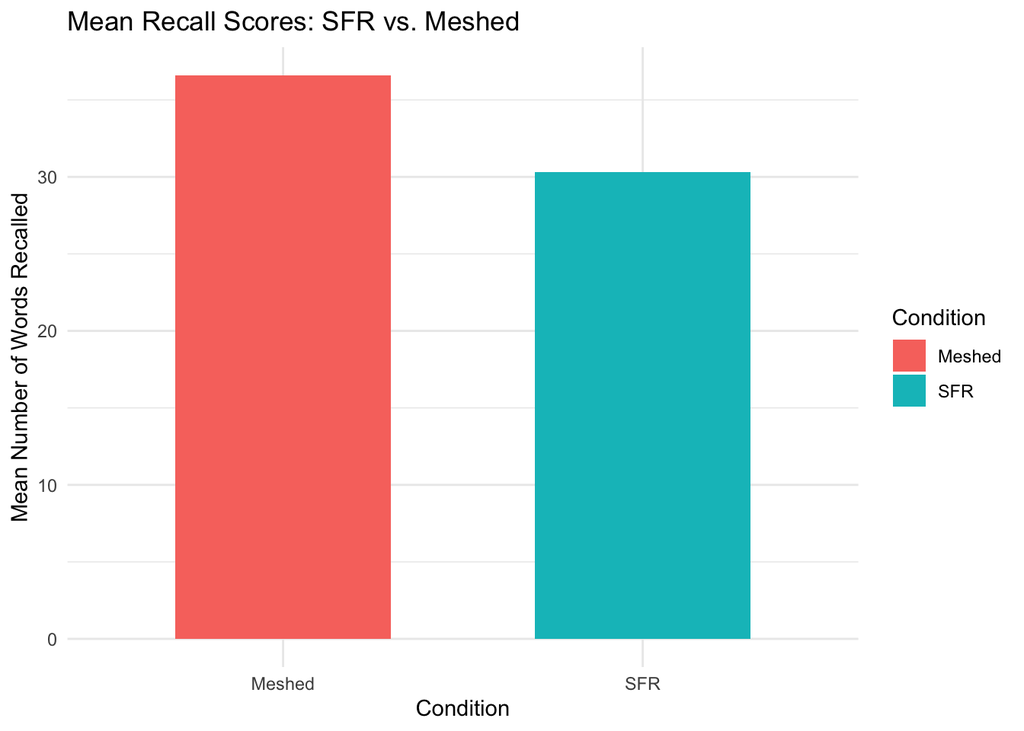

```r
library(ggplot2)

Friendly %>%
  filter(Condition %in% c("SFR", "Meshed")) %>%
  group_by(Condition) %>%
  summarise(Mean = mean(Correct)) %>%
  ggplot(aes(x = Condition, y = Mean, fill = Condition)) +
  geom_bar(stat = "identity", width = 0.6) +
  labs(
    title = "Mean Recall Scores: SFR vs. Meshed",
    x = "Condition",
    y = "Mean Number of Words Recalled"
  ) +
  theme_minimal()
```

### Interpretation

The bar plot visually supports the t-test results, showing that the Meshed group outperformed the SFR group in mean recall scores. The statistically significant p-value ($p = 0.02739$) confirms that this difference is unlikely due to chance.

# t-test: SFR vs Before

```r
# T-Test: SFR vs. Before
t_test_sfr_before <- t.test(Correct ~ Condition, data = Friendly %>% filter(Condition %in% c("SFR", "Before")))
pander(t_test_sfr_before, caption = "T-Test Results: SFR vs. Before")
```

T-Test Results: SFR vs. Before (continued below)

| Test statistic | df | P value | Alternative hypothesis |
| --- | --- | --- | --- |
| 2.196 | 16.45 | 0.04273 * | two.sided |

| mean in group Before | mean in group SFR |
| --- | --- |
| 36.6 | 30.3 |

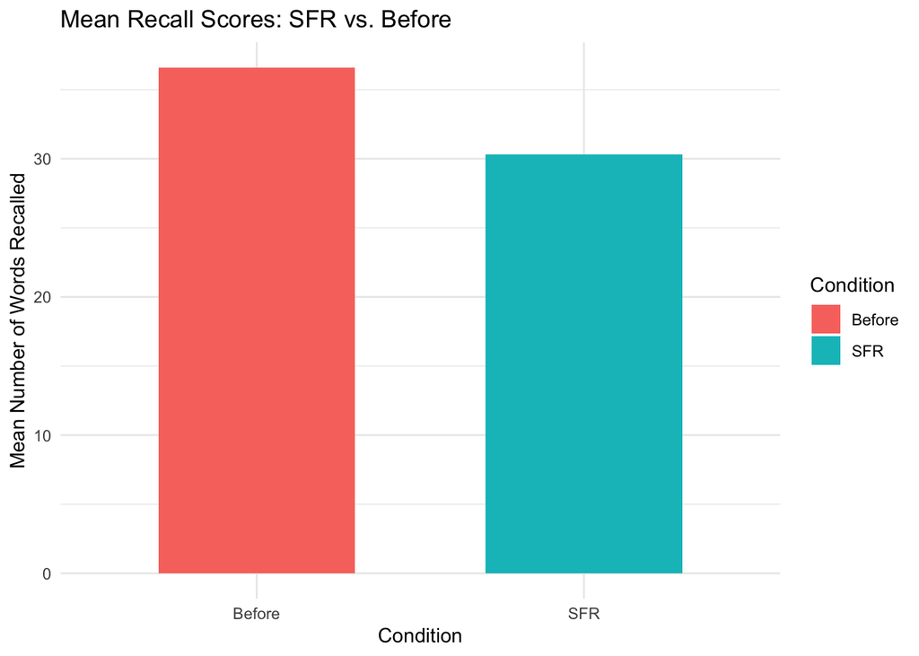

```r
# Visualization for Mean Recall Scores: SFR vs Before
Friendly %>%
  filter(Condition %in% c("SFR", "Before")) %>%
  group_by(Condition) %>%
  summarise(Mean = mean(Correct)) %>%
  ggplot(aes(x = Condition, y = Mean, fill = Condition)) +
  geom_bar(stat = "identity", width = 0.6) +
  labs(
    title = "Mean Recall Scores: SFR vs. Before",
    x = "Condition",
    y = "Mean Number of Words Recalled"
  ) +
  theme_minimal()
```

The Before group significantly outperformed the SFR group **(p=0.04273),** with a mean recall score of 36.6 compared to 30.3.

### Wilcoxon Test (Hypotheses for the Wilcoxon)

# Wilcoxon test: SFR vs Meshed

```r
# Wilcoxon test: SFR vs. Meshed
wilcox_test_sfr_meshed <- wilcox.test(
  Correct ~ Condition,
  data = Friendly %>% filter(Condition %in% c("SFR", "Meshed"))
)
pander::pander(wilcox_test_sfr_meshed, caption = "Wilcoxon Test Results: SFR vs. Meshed")
```

Wilcoxon Test Results: SFR vs. Meshed

| Test statistic | P value | Alternative hypothesis |
| --- | --- | --- |
| 72 | 0.1015 | two.sided |

# Wilcoxon test: SFR vs. Before

```r
wilcox_test_sfr_before <- wilcox.test(
  Correct ~ Condition,
  data = Friendly %>% filter(Condition %in% c("SFR", "Before"))
)
pander::pander(wilcox_test_sfr_before, caption = "Wilcoxon Test Results: SFR vs. Before")
```

| Test statistic | P value | Alternative hypothesis |
| --- | --- | --- |
| 76.5 | 0.04555 * | two.sided |

#Future Studies In the future, it may be of more benefit to use an ANOVA test to see how integration with other techniques may make a difference. This involves the study of how combining the before and meshed with other learning strategies, such as spaced repetition or multimedia learning, might further enhance recall.